# Compare results from EPIC and quanTIseq

Stephanie J. Spielman

2025-01-27

The goal of this notebook is to compare inferences from `EPIC` and `quanTIseq`. Please refer to these notebooks for an initial exploration of the results of each method:

- `explore-epic-results.Rmd` contains an initial exploration of `EPIC` results
- `explore-quantiseq-results.Rmd` contains an initial exploration of `quanTIseq` results

In this notebook, we’ll compare estimates of the fractions of shared cell types as well as estimates of classified vs. unclassified cells. There are several important caveats to bear in mind when interpreting results in this notebook:

- Both methods use strings to label cell types, not cell ontologies. Therefore, while we assume that labels like “CD4 T-cells” (for example) directly correspond between methods, we cannot say this with absolute certainty.
- All `quanTIseq` inferences used the same reference, but there were two references used for `EPIC`. Previously,in the notebook `explore-epic-results.Rmd`, we identified which reference to use for each project; only results from that reference are presented here in comparisons.
- Because all three references across the two methods have different sets of cell types, inferred proportions are not necessarily directly comparable.
  - Results from each inference are necessarily conditioned, to an extent, on the other cell types in the reference and their respective gene signatures, which means that the relative proportions obtained with different methods/references may not be an apples-to-apples comparison.
  - It’s also important to note that higher proportions of classified cells does not strictly imply better performance; it is not known *a priori* what proportion of each sample *should* be classified in the first place (aka, is not tumor tissue).

The table below gives all ScPCA project ids considered, their overall diagnoses, and which `EPIC` reference is considered here.

| Project | High-level diagnosis | `EPIC` Reference |
| --- | --- | --- |
| SCPCP000001 | High-grade glioma | `TRef` |
| SCPCP000002 | Low-grade glioma | `TRef` |
| SCPCP000006 | Wilms tumor | `BRef` |
| SCPCP000009 | CNS tumors | `TRef` |
| SCPCP000017 | Osteosarcoma | `BRef` |

The table below gives all cell types (excluding “other”) which are present in each method/reference. Cell types that are in all methods/references are shown only once on the first line.

| Method | Cell types |
| --- | --- |
| All methods | B cells, CD4 T cells, CD8 T cells, NK cells |
| `EPIC`: `TRef` | CAFs (cancer-associated fibroblasts), Endothelial, Macrophages |
| `EPIC`: `BRef` | Monocytes, Neutrophils |
| `quanTIseq` | M1 Macrophages, M2 Macrophages, Monocytes, Neutrophils, Tregs, Dendritic cells |

Thus, of these options, `quanTIseq` has the most represented cell types, but notably it does not consider non-immune cell types like endothelial.

## Setup

```r
renv::load()
```

```
- Project '~/ALSF/paper/scpca-paper-figures' loaded. [renv 1.0.10]
```

```r
library(ggplot2)
theme_set(theme_bw())
```

### Functions

This chunk defines a helper function to make bar plots of cell type proportions for both methods.

```r
make_barplot <- function(df, color_map, cell_type_column = celltype_consensus) {

  p <- ggplot(df) +
    aes(
      x = sample_id,
      y = proportion,
      fill = forcats::fct_relevel({{cell_type_column}}, names(color_map))
    ) +
    geom_col() +
    scale_fill_manual(values = color_map, name = "cell type") +
    labs(x = "", title = df$project_name[1]) +
    facet_wrap(vars(method), nrow = 2, scales = "free_y") +
    theme(axis.text.x = element_blank())

  return(p)
}
```

This chunk defines a helper function to make a scatterplot comparing common cell types between methods, faceted by cell type and project.

```r
make_comparison_scatterplot <- function(df, project_list) {
  proj_df <- df |>
    dplyr::filter(project_id %in% project_list) |>
    tidyr::pivot_wider(
     names_from = method,
     values_from = proportion
    ) |>
    tidyr::drop_na()

  ggplot(proj_df) +
    aes(x = epic, y = quantiseq) +
    geom_point(alpha = 0.5) +
    geom_abline(color = "red") +
    geom_smooth(method = "lm") +
    facet_grid(
      rows = vars(project_name),
      cols = vars(celltype_consensus),
      scales = "free") +
    theme(aspect.ratio = 1)
}
```

### Paths

```r
results_dir <- here::here("analysis", "bulk-deconvolution", "results")

epic_files <- list.files(
  path = results_dir,
  full.names = TRUE,
  pattern = "*-epic.tsv$"
)
project_ids <- stringr::str_split_i(basename(epic_files), pattern = "-", i = 1)
epic_files <- setNames(epic_files, project_ids)
quantiseq_files <- setNames(
  stringr::str_replace(epic_files, "-epic", "-quantiseq"),
  project_ids
)
```

### Read and prepare data

First, we’ll read in the `EPIC` results and subset to only the reference of interest for each project.

```r
tref_projects <- c("SCPCP000001", "SCPCP000002", "SCPCP000009")
bref_projects <- c("SCPCP000006", "SCPCP000017")

# Read in epic result TSVs and combine into single data frame
epic_raw_df <- epic_files |>
  purrr::map(\(file) readr::read_tsv(file, show_col_types = FALSE)) |>
  purrr::list_rbind(names_to = "project_id")

# Filter based on projects and references
epic_tref <- epic_raw_df |>
  dplyr::filter(
    project_id %in% tref_projects,
    reference == "TRef"
  )

epic_bref <- epic_raw_df |>
  dplyr::filter(
    project_id %in% bref_projects,
    reference == "BRef"
  )

# Create final epic_df with only references of interest for each project
epic_df <- dplyr::bind_rows(epic_tref, epic_bref) |>
  dplyr::rename(celltype = epic_celltype, proportion = fraction)
```

Next, we’ll read in the `quanTIseq` results and combine with the `EPIC` results.

```r
quantiseq_df <- quantiseq_files |>
  purrr::map(\(file) readr::read_tsv(file, show_col_types = FALSE)) |>
  purrr::list_rbind(names_to = "project_id") |>
  dplyr::rename(celltype = quantiseq_celltype)

# combine data frames and set levels for method
deconv_df <- list("epic" = epic_df, "quantiseq" = quantiseq_df) |>
  purrr::list_rbind(names_to = "method") |>
  dplyr::mutate(
    project_name = dplyr::case_match(
      project_id,
      "SCPCP000001" ~ "01: High-grade glioma (TRef)",
      "SCPCP000002" ~ "02: Low-grade glioma (TRef)",
      "SCPCP000006" ~ "06: Wilms tumor (BRef)",
      "SCPCP000009" ~ "09: CNS tumors (TRef)",
      "SCPCP000017" ~ "17: Osteosarcoma (BRef)",
    )
  ) |>
  # arrange columns
  dplyr::select(project_id, sample_id, method, celltype, proportion, project_name)

head(deconv_df)
```

| project_id | sample_id | method | celltype | proportion | project_name |
| --- | --- | --- | --- | --- | --- |
| SCPCP000001 | SCPCS000001 | epic | Bcells | 0.0008765501 | 01: High-grade glioma (TRef) |
| SCPCP000001 | SCPCS000001 | epic | CAFs | 0.0020606142 | 01: High-grade glioma (TRef) |
| SCPCP000001 | SCPCS000001 | epic | CD4_Tcells | 0.0249805460 | 01: High-grade glioma (TRef) |
| SCPCP000001 | SCPCS000001 | epic | CD8_Tcells | 0.0085382879 | 01: High-grade glioma (TRef) |
| SCPCP000001 | SCPCS000001 | epic | Endothelial | 0.1768336951 | 01: High-grade glioma (TRef) |
| SCPCP000001 | SCPCS000001 | epic | Macrophages | 0.0114720047 | 01: High-grade glioma (TRef) |

#### Recode cell types

We’ll now recode cell types so that matching cell types have the same string representation as:

- `B cells`
- `CD4 T cell`
- `CD8 T cells`
- `NK cells`

All methods/references additionally have an “Other” cell type, but these are not necessarily directly comparable because different cell types are present in each reference, so each “Other” encapsulates different cell types.

```r
consensus_df <- deconv_df |>
  dplyr::mutate(
    # this is to make a shared label, not quite a consensus
    celltype_consensus = dplyr::case_when(
      celltype %in% c("Bcells", "B.cells") ~ "B cells",
      celltype %in% c("CD4_Tcells", "T.cells.CD4") ~ "CD4 T cells",
      celltype %in% c("CD8_Tcells", "T.cells.CD8") ~ "CD8 T cells",
      celltype %in% c("NKcells", "NK.cells") ~ "NK cells",
      celltype %in% c("Other", "otherCells") ~ "Other",
      .default = celltype
    )
  ) |>
  dplyr::select(project_name, project_id, sample_id, method, celltype_consensus, proportion)
```

## Cell type proportions

First, we’ll visualize all cell type proportions.

Note the “Macrophage” cell type color scheme:

- “Macrophages.M1” and “Macrophages.M2” are two separate categories in `quanTIseq`, but there is only one category “Macrophages” for all subtypes in `TRef`. There are *no* macrophages in `BRef`.
- Macrophage cell types are all shown in orange, where `quanTIseq` may have two colors but `TRef` will, if present, only have one.

First, we’ll define some shared colors to use for these plots.

```r
# cell types to show when coloring quantiseq & tref together
color_map_tref <- c(
  ### shared
  "Other" = "grey95",
  "B cells" = "firebrick",
  "CD4 T cells" = "#56B4E9",
  "CD8 T cells" = "#0072B2",
  "NK cells" =  "#F0E442",
  ### tref only
  "CAFs" = "#009E73",
  "Endothelial" = "grey30",
  "Macrophages" = "orange2",
  #### quantiseq only
  "Monocytes" = "#CC79A7",
  "Macrophages.M1" = "sienna3",
  "Macrophages.M2" = "sienna1",
  "Dendritic.cells" = "purple",
  "Tregs" = "blue"
)

# cell types to show when coloring quantiseq & bref together
color_map_bref <- c(
  ### shared
  "Other" = "grey95",
  "B cells" = "firebrick",
  "CD4 T cells" = "#56B4E9",
  "CD8 T cells" = "#0072B2",
  "NK cells" =  "#F0E442",
  "Monocytes" = "#CC79A7",
  "Neutrophils" = "grey40",
  #### quantiseq only
  "Macrophages.M1" = "sienna3",
  "Macrophages.M2" = "sienna1",
  "Dendritic.cells" = "purple",
  "Tregs" = "blue"
)
```

And now to the plots:

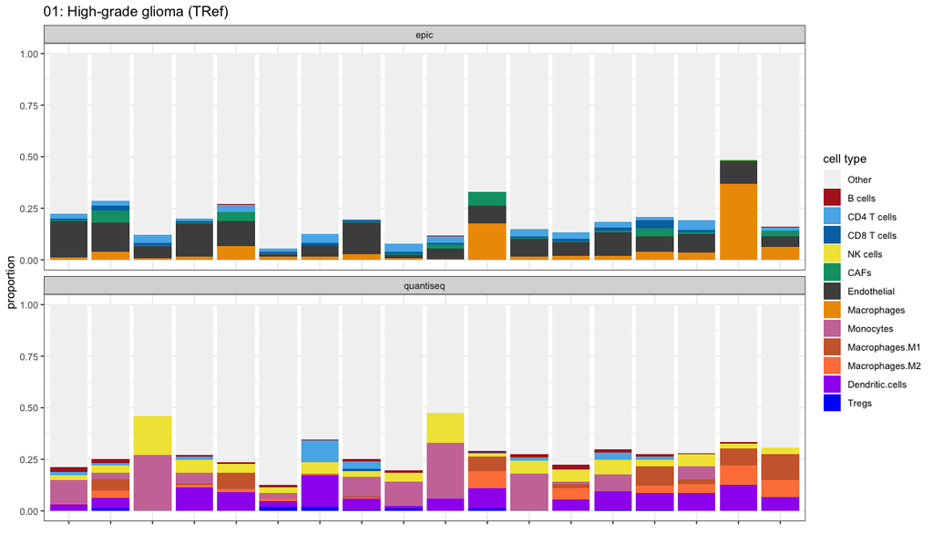

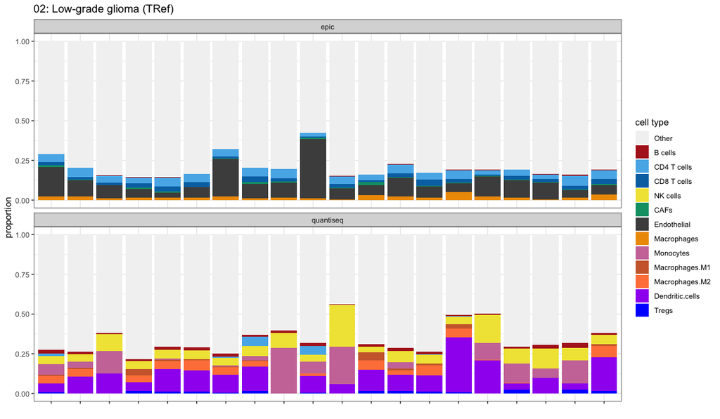

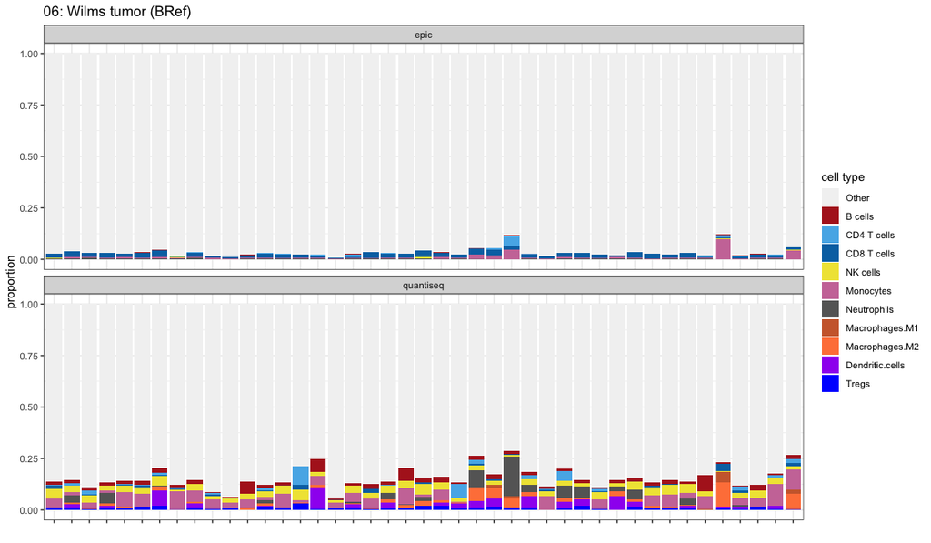

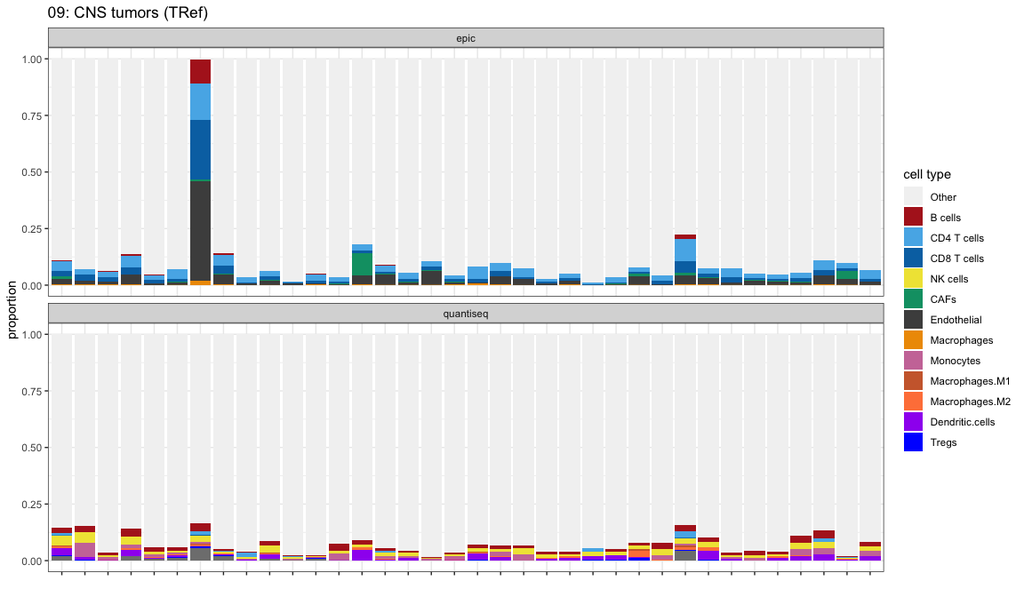

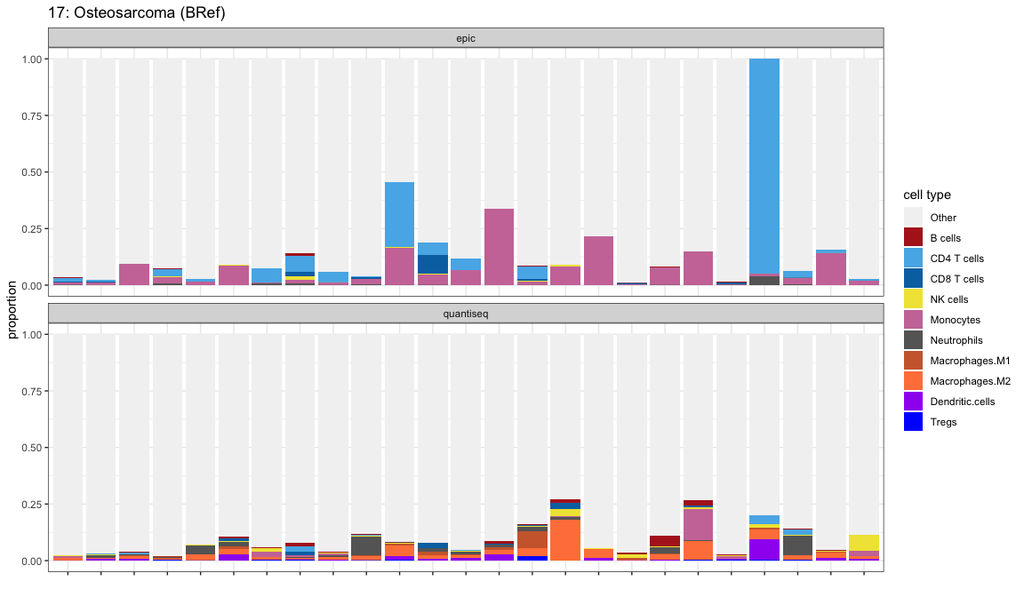

```r
 project_ids |>
  purrr::walk(
    \(pid) {

      # Subset to only this project
      project_df <- consensus_df |>
        dplyr::filter(project_id == pid) |>
        tidyr::drop_na()

      # Assign the colors to use for this plot, depending on the reference
      if (pid %in% tref_projects) {
        color_map <- color_map_tref
      } else {
        color_map <- color_map_bref
      }

       print(make_barplot(project_df, color_map))

    }
  )
```

Next we’ll make a version of these plots which emphasizes shared cell types; cell types that are unique to a reference will be grouped together. In addition, we’ll also collapse the “Macrophages” cell types in `quanTIseq` into a single “Macrophages” (which `TRef` contains) by summing values for M1 and M2.

```r
# sum the quantiseq macrophage to be a single cell type
quantiseq_macro <- deconv_df |>
  dplyr::filter(stringr::str_starts(celltype, "Macrophages.M")) |>
  dplyr::group_by(project_name, project_id, sample_id, method) |>
  dplyr::summarize(proportion = sum(proportion)) |>
  dplyr::ungroup() |>
  dplyr::mutate(celltype_consensus = "Macrophages")

# update consensus df to have this new macrophage grouping for quantiseq
consensus_macrophages_df <- consensus_df |>
  dplyr::filter(
    !stringr::str_starts(celltype_consensus, "Macrophages.M")
  ) |>
  dplyr::bind_rows(quantiseq_macro)
```

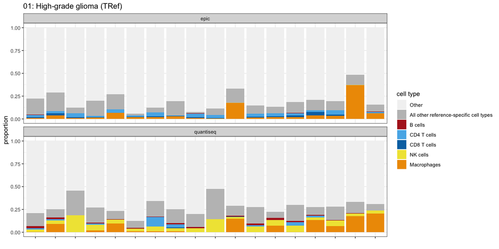

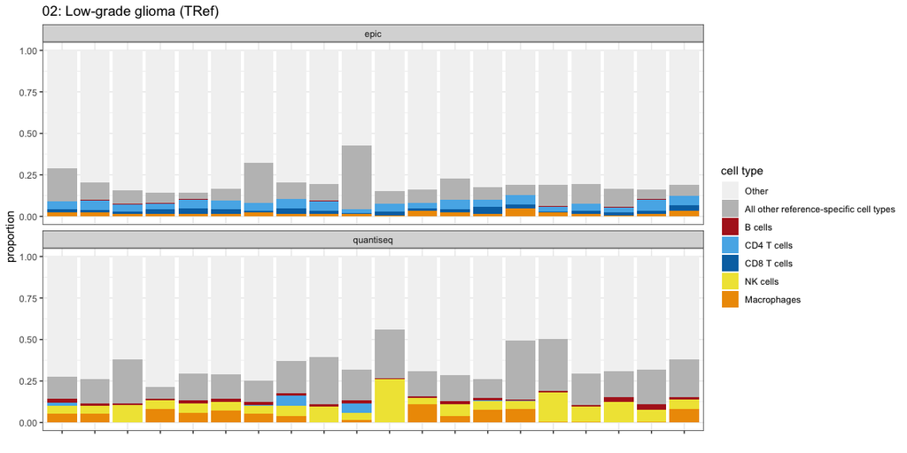

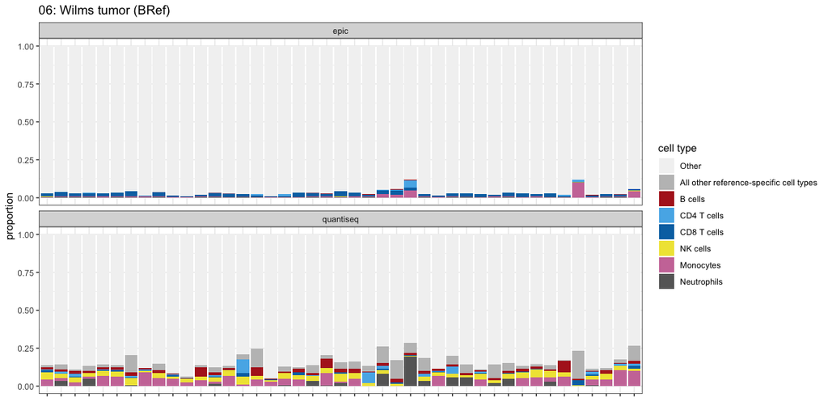

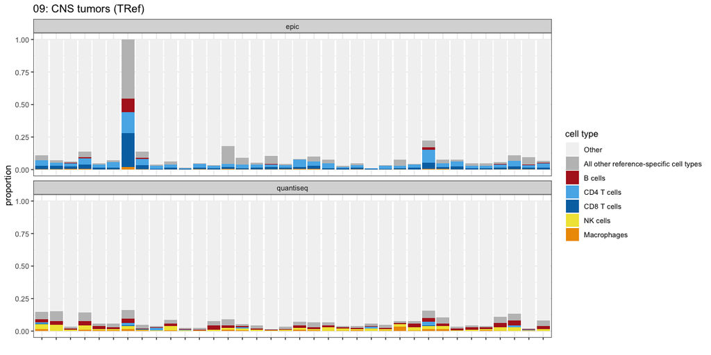

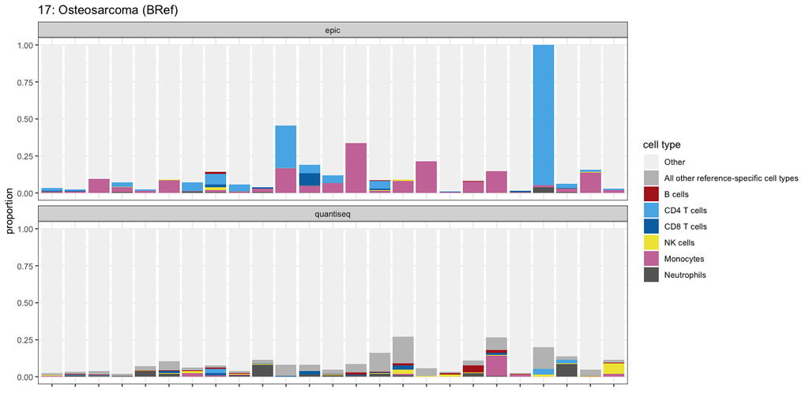

```r
# Prepare some plotting colors
tref_shared <- c("B cells", "CD4 T cells", "CD8 T cells", "NK cells", "Macrophages")
bref_shared <- c("B cells", "CD4 T cells", "CD8 T cells", "NK cells", "Monocytes", "Neutrophils")
other_celltypes_label <- "All other reference-specific cell types"
other_colors <- c(
  "Other" = "grey95",
  "All other reference-specific cell types" = "grey75"
)

tref_shared_color_map <- c(other_colors, color_map_tref[tref_shared])
bref_shared_color_map <- c(other_colors, color_map_bref[bref_shared])


# plot each project
project_ids |>
  purrr::walk(
    \(pid) {

      # determine which cell types to plot
      if (pid %in% tref_projects) {
        plot_celltypes <- tref_shared
        color_map <- tref_shared_color_map
      } else {
        plot_celltypes <- bref_shared
        color_map <- bref_shared_color_map
      }

      # Subset to only this project and update celltypes to be:
      # - In the shared vector
      # - "Other"
      # - not other but unshared
      project_df <- consensus_macrophages_df |>
        dplyr::filter(project_id == pid) |>
        tidyr::drop_na() |>
        dplyr::mutate(
          celltype_grouped = ifelse(
            celltype_consensus %in% c("Other", plot_celltypes),
            celltype_consensus,
            other_celltypes_label
          ),
          celltype_grouped = forcats::fct_relevel(celltype_grouped, names(color_map)),
          celltype_grouped = forcats::fct_rev(celltype_grouped)
        )


      print(make_barplot(project_df, color_map, cell_type_column = celltype_grouped))

    }
  )
```

## Proportions of classified cells

Next, we’ll look specifically at the distributions of the total classified proportion (i.e., 1 - “other”) across samples. For this, we’ll only consider samples which are not essentially fully classified. There are two samples which `EPIC` fully classified:

```r
fully_classified_df <- consensus_df |>
  dplyr::filter(
    celltype_consensus == "Other",
    proportion <= 0.01
  )
fully_classified_df
```

| project_name | project_id | sample_id | method | celltype_consensus | proportion |
| --- | --- | --- | --- | --- | --- |
| 09: CNS tumors (TRef) | SCPCP000009 | SCPCS000135 | epic | Other | 2.011327e-03 |
| 17: Osteosarcoma (BRef) | SCPCP000017 | SCPCS000612 | epic | Other | 6.138643e-06 |

First, we’ll visualize these distributions as sina plots:

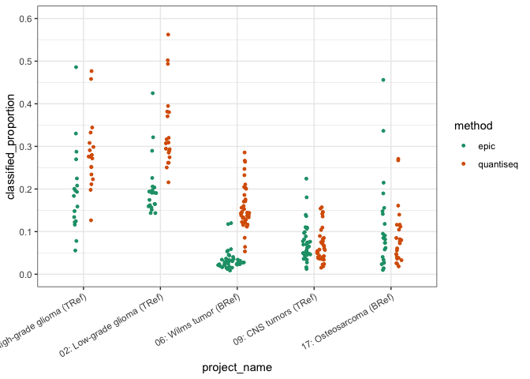

```r
classified_prop_df <- consensus_df |>
  dplyr::filter(
    !(sample_id %in% fully_classified_df$sample_id),
    celltype_consensus == "Other"
  ) |>
  dplyr::mutate(
    classified_proportion = 1 - proportion
  )

ggplot(classified_prop_df) +
  aes(x = project_name, y = classified_proportion, color = method) +
  ggforce::geom_sina(size = 1, position = position_dodge(width = 0.4)) +
  scale_y_continuous(
    limits = c(0, 0.6),
    breaks = seq(0, 0.6, 0.1)
  ) +
  scale_color_brewer(palette = "Dark2") +
  theme(axis.text.x = element_text(angle = 30, hjust = 1))
```

Distributions of classified proportions, across all projects, are generally below 0.4 with a handful of outliers. As noted in the barplots, `EPIC` tends to classify lower proportions of each sample compared to `quanTIseq`, but whether this is due to a) the method itself, b) fewer cell types in the `EPIC` signature gene lists, or c) marker gene information in the signature gene matrices themselves would require further investigation.

## Relationship between shared cell types

In this section we’ll look more closely at shared cell types between references to directly compare inferred quantities.

Next, we can ask whether there is any relationship between these quantities. We’ll also include a panel for the proportion of classified cells.

In plots below, projects that use `TRef` in `EPIC` are shown first, and then `BRef`. In each panel, the red line is `y=x` and the blue line with CI is the regression line (due to faceting, coordinates are not 1:1 on the axes though).

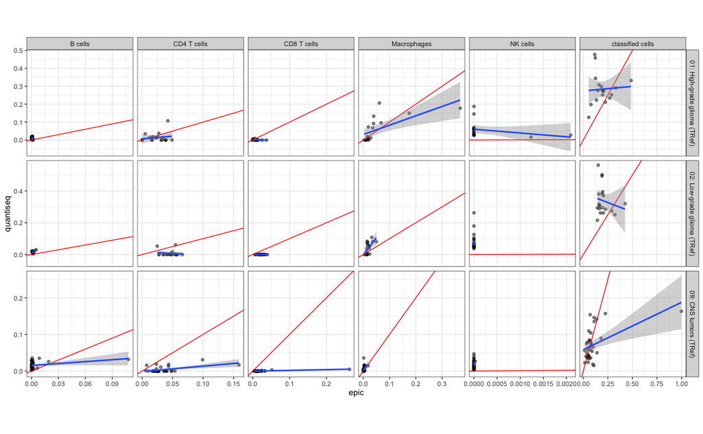

```r
consensus_macrophages_classified_df <- consensus_macrophages_df |>
  # switch other to classified cells, and make it the last level
  dplyr::mutate(
    proportion = ifelse(
      celltype_consensus == "Other",
      1 - proportion,
      proportion
    ),
    celltype_consensus = ifelse(
      celltype_consensus == "Other",
      "classified cells",
      celltype_consensus
    ),
    celltype_consensus = forcats::fct_relevel(celltype_consensus, "classified cells", after = Inf)
  )
make_comparison_scatterplot(consensus_macrophages_classified_df, tref_projects)
```

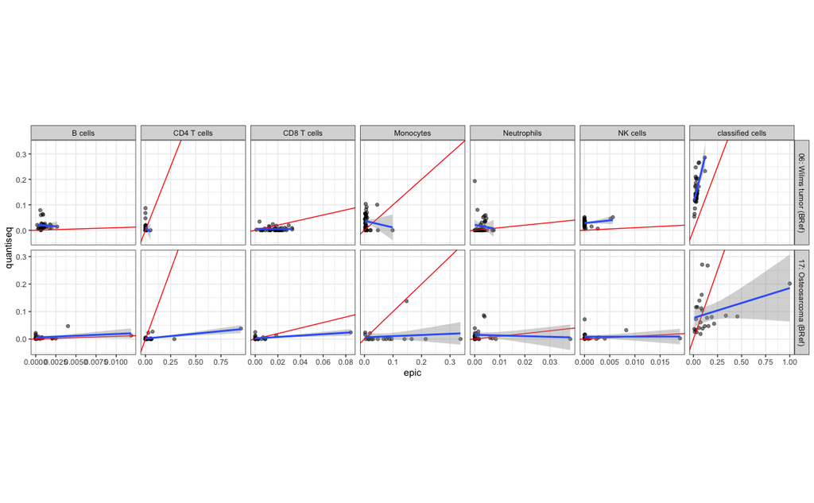

```r
make_comparison_scatterplot(consensus_macrophages_classified_df, bref_projects)
```

## Overall conclusions

Overall, there are substantial differences between `quanTIseq` and `EPIC` results using built-in references. If we want to proceed with bulk deconvolution, moving forward, we might consider:

- Devising our own reference to use with at least one of these methods
- Revisiting gene IDs to ensure as high as possible correspondence between the `EPIC` reference profile and input TPM data
- Performing initial comparisons to cell typing performed on the single-cell level to help identify which method might be more accurate